# A brief summary of the Malaria Box spreadsheet

Neil Saunders

14/10/2016

## Introduction

This document is (so far) just a quick look at the Medicines for Malaria Venture spreadsheets downloaded via [the MMV website](http://www.mmv.org/research-development/malaria-box-supporting-information).

## Compounds by source

First, we download the spreadsheets containing 1. the full public dataset and 2. the set of 400 compounds in the malaria box.

```r
mmvpublic <- "http://www.mmv.org/sites/default/files/uploads/docs/RandD/Dataset.xlsx"
mb400 <- "http://www.mmv.org/sites/default/files/uploads/docs/RandD/MalariaBox400compoundsDec2014.xls"

mmv <- read.xls(mmvpublic, stringsAsFactors = FALSE)
mbox400 <- read.xls(mb400, stringsAsFactors = FALSE)
```

The *sources* column in the malaria box is confusing, in that entries may be labelled with multiple sources, semi-colon delimited. Sometimes even the same source several times *e.g.* “GNF;GNF;GNF”. This piece of code replaces sources with unique sources *e.g.* “GNF;GNF;GSK” becomes “GNF;GSK”.

```r
mbox400$s <- sapply(sapply(strsplit(mbox400$source, ";"), function(x) unique(x)),
    function(y) paste(y, collapse = ";"))
```

Now we can plot the full public dataset by source. Shows that GSK dominates, followed by GNF.

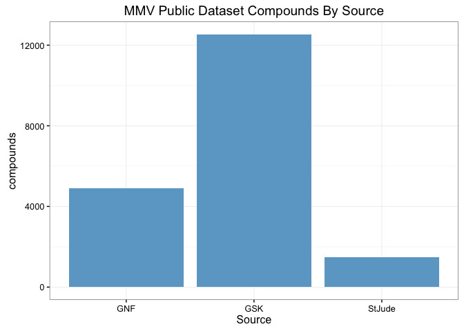

Followed by the malaria box dataset. Again GSK and GNF are predominant, although now GNF comes top.

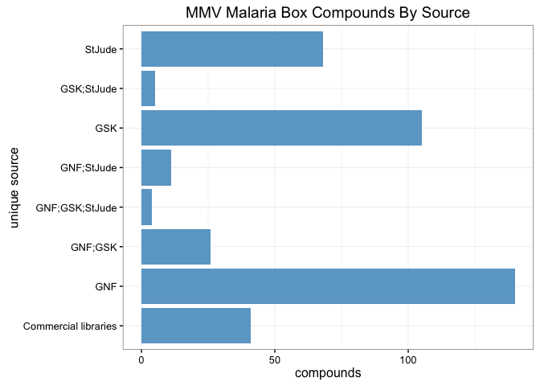

## Activity

Violin plots show distribution of activity. Looking first at the full public dataset we see two peaks at low concentrations for GSK and GNF compounds. By contrast, activity of St. Jude compounds is spread across a wider range with more compounds at higher concentrations.

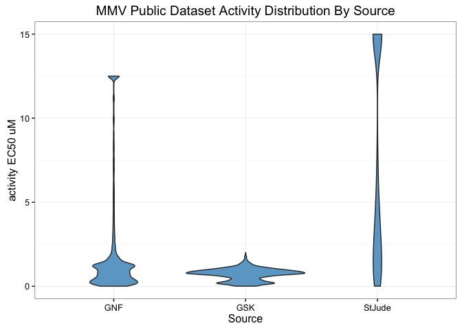

Turning to the malaria box, we see two broad types of distribution. In the first, EC50 is spread over a wide range with broad peaks at higher and lower concentrations. In the second, concentration has a narrower range and is often centered around 1000 nM (see especially the commercial libraries).

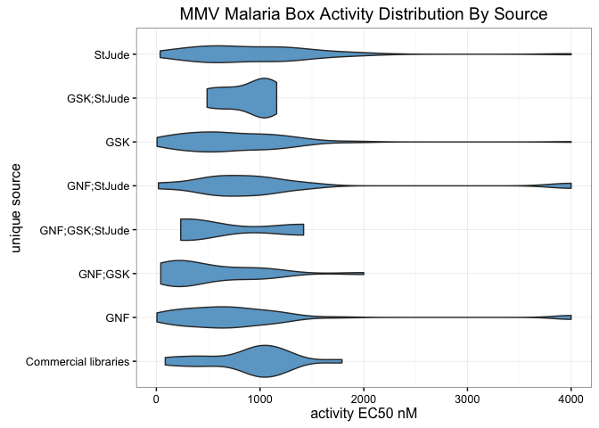

## Other numerical data

Here’s a preview of other numerical data in the malaria box spreadsheet which could be analysed. Note: wide table, scroll right to view.

```r
names(mbox400)
```

```
##  [1] "HEOS_COMPOUND_ID"   "Batch_No_March2012" "Batch_No_June2012"
##  [4] "Batch_No_April2013" "Smiles"             "percent_inh...2.uM"
##  [7] "percent_inh...5.uM" "EC50_nM"            "ChEMBL_NTD_ID"
## [10] "source"             "CHEMBL.EC50.in.uM"  "Set"
## [13] "Ro5_ViolationCount" "NplusO_Count"       "Molecular_Weight"
## [16] "Num_H_Donors"       "ALogP"              "Comment"
## [19] "s"
```

```r
kable(head(mbox400[, c(1,6:8,11,13:17)]))
```

| HEOS_COMPOUND_ID | percent_inh…2.uM | percent_inh…5.uM | EC50_nM | CHEMBL.EC50.in.uM | Ro5_ViolationCount | NplusO_Count | Molecular_Weight | Num_H_Donors | ALogP |
| --- | --- | --- | --- | --- | --- | --- | --- | --- | --- |
| MMV019066 | NA | 67 | 140 | 1.038295576 | 0 | 7 | 359.3996 | 2 | 1.599 |
| MMV665941 | NA | 96 | 255 | 0.6195 | 0 | 4 | 389.5331 | 1 | 4.763 |
| MMV396680 | NA |  | 92.8 | NA | 1 | 5 | 476.9018 | 1 | 5.664 |
| MMV666601 | NA | 94 | 154 | 2.325 | 2 | 8 | 637.7198 | 0 | 7.027 |
| MMV008294 | NA | 96 | 232 | 1.779 | 0 | 6 | 380.4370 | 1 | 4.710 |
| MMV011259 | NA |  | 85.7 | NA | 0 | 5 | 321.3004 | 1 | 4.628 |